# Win 11 安裝步驟與設置(25H2)

目錄》

- 安裝步驟
- 建議的設定
- 無法安裝與硬碟處理
- 開啟主機板虛擬化技術

# 25H2 安裝作業系統說明

從 Windows 11 24H2 版開始，網路組不再提供預安裝應用程式的作業系統安裝媒體，而是提供說明文件，讓同修從微軟官方下載、製作安裝媒體(USB)，並提供軟體下載清單文件供選用安裝。(詳見：Windows11_25H2安裝說明.html)

官方 Windows 11 安裝時主機板需要支援並開啟 TPM (信賴平台模組)、開啟 Secure Boot、記憶體至少要 4G，可以透過 Rufus 繞過這些限制。不過電腦記憶體如果連 4G 都不到的話其實用 Win 10 就好。主機板如果有提供 TPM 功能，建議在 BIOS 中設為啟用，方便日後升級。

Windows 11 只支援 UEFI 模式，使用 USB 安裝碟開機時請選 UEFI 模式開機。無法開機、安裝的處理請看這裡。

## 安裝步驟

🚩**建議：請離線安裝！ (斷開網路線)**

如果沒有使用 Rufus 製作的 USB 安裝，除非使用微軟帳號連線安裝，否則需要手動處理繞過限制。如果不想使用微軟帳號安裝，**建議一開始就用 Rufus 製作安裝碟**。

25H2 與 24H2 其實內核是相同的，安裝介面基本上都差不多。以下是安裝步驟圖解。從 USB 安裝碟開機之後，如下動畫圖操作即可：

[figure not shown]

購買的金鑰也建議等安裝好系統再輸入啟用，因為安裝過程建議斷開連線(拔除網路線、不連 WiFi)。

然後選擇要安裝的作業系統版本，再點「下一步」，如下圖：

[figure not shown]

出現授權畫面，如下圖點「接受」：

[figure not shown]

接下來要選擇硬碟進行安裝，這裡可能遇到不同情況，以下用新硬碟為範例，其他幾種情況在後面另有說明。24H2 之後介面稍有不同(第二圖)。**注意**：如果電腦中有多個實體硬碟，為避免選錯磁碟，建議把其餘磁碟的電源與連接線先拔掉)

**🚩直接用整個硬碟安裝(不分割)：**

直接用整個磁碟安裝請點選磁碟之後，點下一步，程式會自動分割需要的磁區、安裝，如下圖是舊版，25H2 介面如第二圖：

[figure not shown]

[figure not shown]

**🚩分割磁碟後安裝：**

按：現在幾乎電腦的系統碟都使用 SSD，加上價格也親民，很多人 1TB 的 SSD 直接安裝系統不分割。這沒問題，實際請依照個別情況斟酌，一般建議 C 碟不要太小，除非必要，否則 500G 以下的 SSD 不分割為宜。

此範例是分割 240G 的硬碟，其實 240G 通常不用分割，這個教學示範分割 100G 作為安裝系統之用 (圖片是以前製作的，如果要分割，建議系統磁區給大點，如 256G 或 500G)，剩下的部分可以順手分割、格式化，也可以進 Windows 再做。以下是舊版的圖例，後面有 24H2 之後的介面。

①點要用來安裝的磁碟，②再點新增，然後③輸入想要分割作為 C 碟的大小。如本例使用 100G，那就是 1024 * 100 = 102400，然後④點「套用」，⑤程式提示會自動建立需要的分割，點「確定」，如下圖：

[figure not shown]

剩餘的部分可以新增另一磁區，再進行格式化，圖略。

接著點要安裝作業系統的磁區(💥別選錯了！如果剛有做格式化會停在那一磁區，**記得點回要安裝的磁區**)，然後點「下一步」，如下圖：

[figure not shown]

**24H2 之後的磁碟分割大同小異**，以下是 1TB 的硬碟為例，分割 256GB 來安裝(1024*256=262144)。①選擇要分割的磁碟，②點「建立磁碟分割」，③輸入要分割的大小，④點「套用」，如下圖：

[figure not shown]

程式會自動建立需要的磁區，不管有無在此把剩餘的磁碟空間建立磁區，要安裝時請先確認點選的是正確的磁區，然後點「下一步」，如下圖：

[figure not shown]

開始安裝，期間可能會自動從新開機，所需時間依電腦等級而定。

等到電腦畫面停在詢問國家地區，就可以開始下一步。接下來的步驟如下動畫圖所示操作即可：

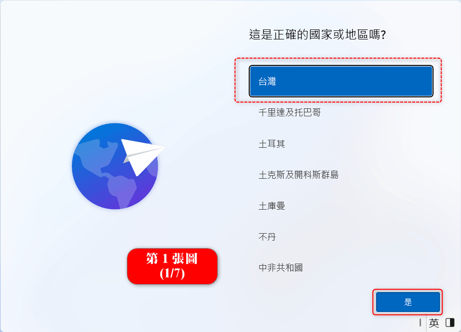

說明：如果不是透過 Rufus 製作繞過限制的 USB，可能會在第4圖出現不一樣的畫面，建議使用 Rufus 製作 USB。使用者名稱建議不要用中文，密碼也暫時不設置，有需要等安裝完成進入系統再設置。

另外有些人可能購買微軟 Office 或是其他原因，需要以微軟帳號登入系統。也建議等系統安裝完成之後再設置較好，可以避免許多問題。

這樣就完成 Windows 的安裝。其他需要應用程式可以參考：軟體下載清單25H2.html 內的連結下載、安裝。

## 建議的設定

系統安裝之後，還有一些必要的的動作：

- 安裝驅動程式
- 下載、安裝、設置需要的應用程式
- 進行系統更新與設置
- 根據個別需求進行系統設定
- 設置或匯入個人設定、帳密、書籤、憑證...等
- 移除用不到的應用程式或內建程式
- 清理系統
- 備份系統

因為每個人的需求不同，安裝的應用程式與適合的設定也不一樣，所以在此僅提供一些適用於大多數人的設置供參考。

### 介面與檔案總管

檔案總管以**本機**開啟、隱私權中**不顯示**文件與資料夾歷史，如下圖：  
隱私權中顯示文件與資料夾雖然便利於開啟歷史文件，但是累積久了會造成效能降低，請斟酌開啟。

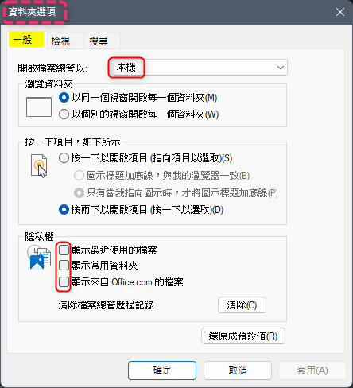

顯示**副檔名**、啟用**精簡檢視**，如下圖設置：

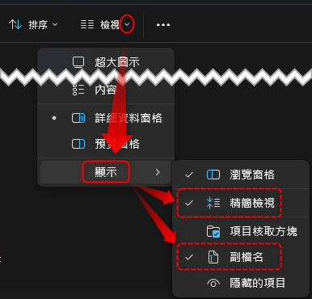

**使用舊式右鍵選單**：Windows 11 使用的右鍵選單其實並不好用，推薦設成 Windows 10 的模式，請在「軟體下載清單25H2.html」->**其他設定檔**下載**切換 Windows 11 右鍵選單**來設置。

### 相關設定

**個人化：**沒有啟用的 Windows 一旦連線之後就無法變更個人化設置 (桌布可以對圖片按右鍵選「設為桌面背景」)。當安裝完成進入桌面，如果系統沒啟用，又想設置個人化項目，如桌布、桌面圖示、色彩、佈景主題...等，**請在連線之前，先把個人化設置做好**。

**電源設定**：桌機不論選用何種電源計畫，建議都從**控制台->電源選項**，選套用的電源計畫的「變更計畫設定」->「變更進階電源設定」，把「關閉硬碟前的時間」設為 0(永不)，如下圖：

[figure not shown]

🎈筆電請依照實際使用情況設置。

**啟用系統保護、關閉遠端**

啟用系統保護：對桌面『本機』按右鍵 → 內容 → 中間位置的『系統保護』，點保護設定內的 C 碟 → 設定 → 點『開啟系統保護』將下方的最大使用量拉到約 2 ~ 5% 即可(視 C 碟大小而定) → 確定，如下圖：

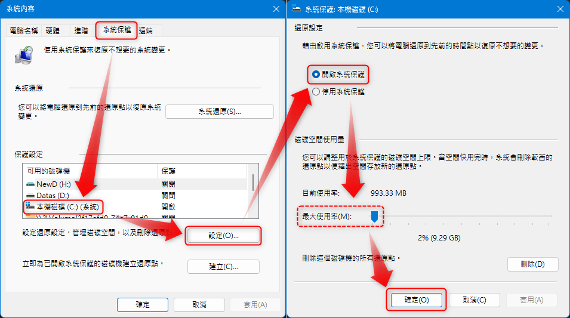

關閉遠端：同上開啟系統內容的「遠端」頁籤，把遠端協助的打勾取消 -> 確定，如下圖：

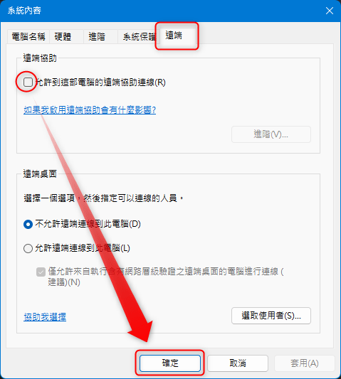

### 設定懶人包：

**以上**如果懶得一一去設置，也符合需求的話，我們提供 PowerShell 指令，在 25H2 資料夾內有一個 WindowsTweaks.ps1 文件，請將此文件複製到電腦中。

以系統管理員身分開啟 PowerShell 或終端機，先切換到文件所在位置，如以下範例是 D 碟根目錄，然後分別執行以下指令：

- cd D: 按 Enter
- Set-ExecutionPolicy RemoteSigned -Scope CurrentUser 按 Enter
- .\WindowsTweaks.ps1 按 Enter

**以下設置請根據個人需求設置。**

**關閉不必要的通知**：從**設定** -> 系統 -> 通知，往下拉到最後，點開「其他設定」，如下圖把三個通知打勾都取消：

[figure not shown]

**文字大小：**每個人習慣的文字大小可能不同，建議盡量**不要**在「系統->顯示器->縮放與配置」中變更。而是優先在**「設定->協助工具->文字大小」**中調整顯示的文字大小，如下圖：

[figure not shown]

**隱私權與安全性：**按照每個使用者所需不同，開啟權限即可，懶得設置可以用系統預設值。關於應用程式使用權限，可以把用不到的都關閉，只開啟如：攝影機、麥克風等會用到的權限，其他的先關閉，等需要時再開啟即可。

**Windows Update：**一般情況 Windows Update 保持預設即可。建議的設置一個是「進階選項」中的「當需要重新啟動才能完成更新時，通知我」要**開啟**。另一個是**關閉傳遞最佳化**，如下圖設置：

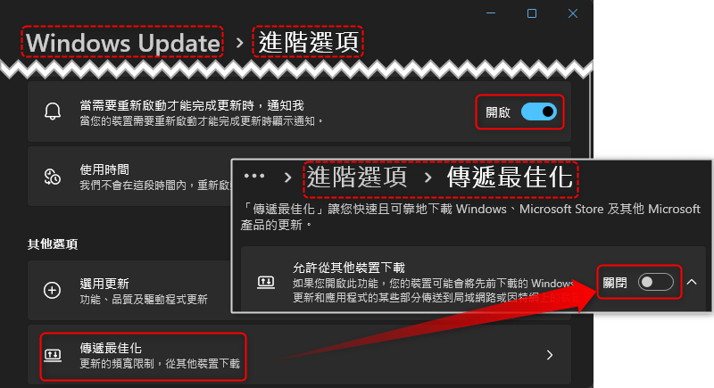

其實整個 Windows 的設定多如牛毛，每個人的需求又不同，近年來接到很多反饋，**有些要求甚至是互相衝突的**，很難用一套設定標準讓所有的使用者滿意。因此只提供一些實用的建議供大家參考，實際請按照每個使用者的習慣或需求來設置吧！

## 無法安裝與硬碟處理

此部分的圖稍舊但實際處理的方式都相同，一樣可以參考。這個問題常見於舊硬碟。

無法安裝通常是要安裝的硬碟採用 MBR 分割，需要先轉換到 GPT 格式才能安裝。更麻煩的是主機板不支援 UEFI，甚至使用此 USB 開機都會有問題。這樣的話不建議安裝 Windows 11。所以**能安裝的先決條件是主機板支援 UEFI**，只要不是太舊的板子應該都支援。

有的板子 BIOS 雖然支援 UEFI，以 USB 碟開機卻無法正常安裝，出現如下圖：

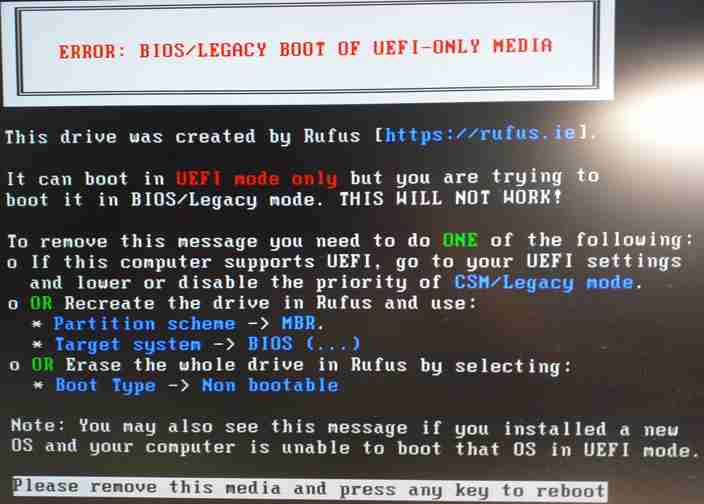

這是主機板設置為傳統韌體優先使用，請在開機時**手動選擇** UEFI 從 USB 開啟，或是在 BIOS 中設為只使用 UEFI 或 UEFI 優先，如下圖：

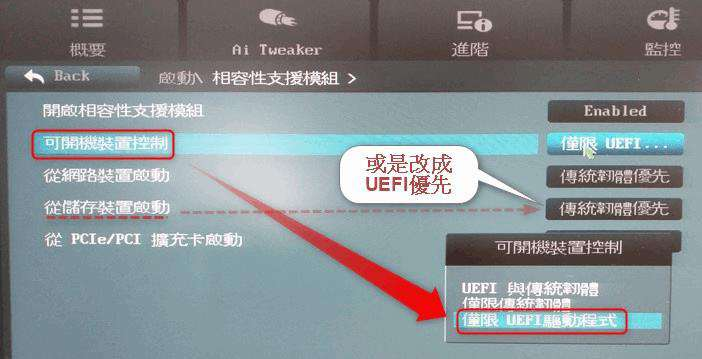

### 磁碟無法安裝 Windows

遇到安裝磁碟的時候出現 Windows 無法安裝的訊息，這是因為安裝 Windows 11 只支援 GPT 格式，不支援傳統的 MBR 格式，如下圖：

[figure not shown]

如果點「顯示詳細資料」(上圖紅色虛線)可以看到無法安裝的說明對話視窗，如下圖：

[figure not shown]

硬碟要轉換成 GPT 格式才能安裝。把**硬碟從 MBR 轉到 GPT 格式，裡面的資料都會被刪除**，如果有需要保留的話，請先複製到其他磁碟。

**🚩轉換硬碟格式步驟🚩**

分別選取要安裝磁碟的**每一個磁區**，然後點「刪除」，如下圖：

[figure not shown]

刪除磁碟(區)的時候會出現詢問視窗，請點「確定」，如下圖：

[figure not shown]

**重要**：一定要選對磁碟，電腦中有多個實體硬碟時更容易弄錯。建議先把其他硬碟的電源線、連接線拔掉，以免誤選。

磁區全部刪除之後就可以看到完整的磁碟，無法安裝的訊息已經消失，這時就可以按照上述教學開始安裝作業系統，如下圖：

[figure not shown]

## 開啟主機板虛擬化技術

安裝作業系統時建議把主機板 BIOS 中的虛擬化技術開啟。因為很多學員都需要在主機上執行 VMware Workstation，沒開啟可能會虛擬機客戶端 (Guest)無法正常執行。

以前的主機板虛擬化技術大多預設為關閉，這幾年因為遊戲興起，使用模擬器玩遊戲的人增多(模擬器也是一種虛擬機)，主機板廠才跟著把虛擬化技術預設為開啟。即使如此，最好在安裝作業系統時順便看看主機板的虛擬化技術是否有打開？或是平常幫學員整理電腦時一併檢查看看。

除了開機時進入 BIOS 查看，已經開機的電腦也可以從工作管理員查看。開啟工作管理員，從「效能」的「CPU」中可以看到『**模擬： 已啟用**』就表示此電腦主機板的虛擬化技術已經開啟，如下圖：

[figure not shown]

如果主機板未開啟虛擬化技術(不要太舊或太偏門的主機板都有支援，只不過未必有啟用)，就要到 BIOS 設定中開啟。因為廠牌、型號、版本不同，開啟虛擬化的位置不盡相同，所以有時候很難快速找到。真的找不到可以到主機板的官網查看使用手冊。

有時候官網也沒有相關手冊或說明，沒錯，不是每個廠商對使用者都會用心，所以我選主機板的依據之一，就是看有無比較完整的使用手冊。連手冊都草草應付，很難指望在其他地方會多用心... 扯遠了，通常一開機按「Delete」鍵就可以進入 BIOS 設定畫面，少數主機板是 F2、Esc 或是其他按鍵。

常見主機板設置虛擬化技術的可能位置：

技嘉 ( GigaByte )：在 Settings 或 BIOS Feature 或 Chipset 中  
微星 ( MSI )：在 OC 的 CPU Feature 中  
華碩 ( ASUS )：在 Advaced 的 CPU Configuration 或 System Agent Configuration 中  
傳統 BIOS ( Legacy )：在 Advanced 中

這幾年主機板 BIOS 變化相當大，沒看過的板子一時之間會不知從何處著手，查看官方手冊看似費事，有時候卻是最便捷的。如下圖是技嘉官方手冊上的圖例，找到虛擬化技術之後改成 Enabled(啟用)：

[figure not shown]

虛擬化技術在 Intel 叫 VT，AMD 的板子上叫 SVM，仔細找找都能找到。

**注意：**改好之後記得**按 F10 鍵儲存**，再次開機才會生效。

## 附：更新 BIOS

通常電腦跑得很順的時候不需要更新 BIOS。但是這兩年新買的主機板最好在安裝 OS 之前檢查有無新版 BIOS 可更新，因為軟硬體都更新頻繁、駭客努力鑽漏洞，使得更新 BIOS 的機會增多。

因為有些是修復 bug，讓系統較穩定；有的是安全性更新，沒更新讓人不放心。目前的主流主機板大部分都設有更新驅動與 BIOS 的軟體，可以在安裝 Windows 後自動檢測驅動、BIOS 有無更新。總之都安裝新 OS 了，就順便檢查一下 BIOS 版本吧！

當然更新 BIOS 有風險，只要運氣不是太糟，如更新時遇到停電，失敗的機率其實不高。現在的主機板設置也讓風險降低很多，通常更新不成功都會返回原先的版本。即使真的搞不定無法開機，個人的經驗是保固內送回原廠刷 BIOS 是不收費的，就是費事費時。

每家主機板廠都有更新 BIOS 說明，如果沒把握，請先看看官網怎麼說，以下是三大主機板廠的一些說明：

- 華碩：[說明](https://www.asus.com/tw/support/FAQ/1044348/)
- 技嘉：[說明](https://tw.aorus.com/blog/How-to-Update-Your-BIOS-tw.php)
- 微星：[說明](https://tw.msi.com/support/technical_details/MB_BIOS_Update)，[影片說明](https://www.youtube.com/watch?v=39Adeqad_84)

網路上相關資料甚多，查詢時請注意時間、版本等是否相符，也不能全信。最好還是以官網為準。不確定的話還能電話或網頁線上諮詢，這方面國內幾家廠商都做得不錯，需要時可以多加利用。